# K-Means Clustering

This notebook will be walking through the process of clustering the iris dataset by species. This will be done by showing support of statistical differences between groups and running a model to classify the groups

```r
# Installs
install.packages("cowplot")
install.packages("ggpubr")
```

```r
# Libraries
library(cowplot)
library(ggpubr)
```

A first look at the data shows signs of linear patterns in the data and more importantly signs of grouping. We can observe the four fields and three different flower species

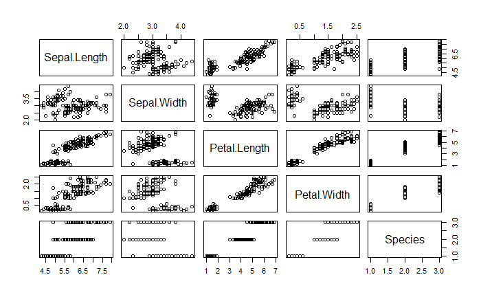

```r
plot(iris)
```

Summary statistics for dataset

```r
summary(iris)
```

```
  Sepal.Length    Sepal.Width     Petal.Length    Petal.Width
 Min.   :4.300   Min.   :2.000   Min.   :1.000   Min.   :0.100
 1st Qu.:5.100   1st Qu.:2.800   1st Qu.:1.600   1st Qu.:0.300
 Median :5.800   Median :3.000   Median :4.350   Median :1.300
 Mean   :5.843   Mean   :3.057   Mean   :3.758   Mean   :1.199
 3rd Qu.:6.400   3rd Qu.:3.300   3rd Qu.:5.100   3rd Qu.:1.800
 Max.   :7.900   Max.   :4.400   Max.   :6.900   Max.   :2.500
       Species
 setosa    :50
 versicolor:50
 virginica :50
```

Looking at the two graphs below we can observe that species tend to group based on Sepal and Petal features

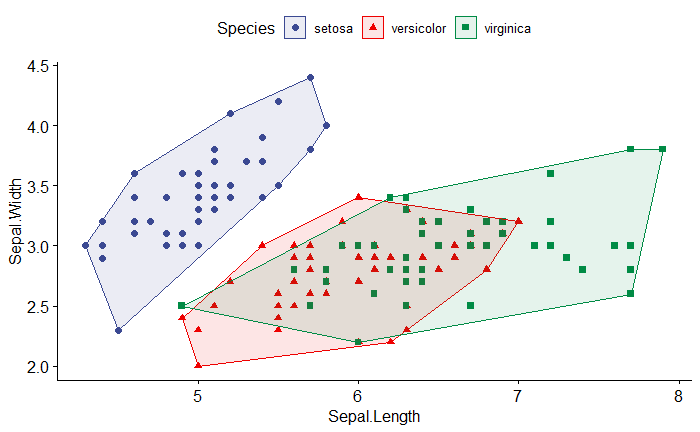

```r
par(mfrow=c(1,2))    # set the plotting area into a 1*2 array


# Plotting Sepal Length & Width by Species
ggscatter(iris, x = "Sepal.Length", y = "Sepal.Width",
          color = "Species", palette = "aaas",
          shape = "Species",
          ellipse = TRUE, ellipse.type = "convex")
```

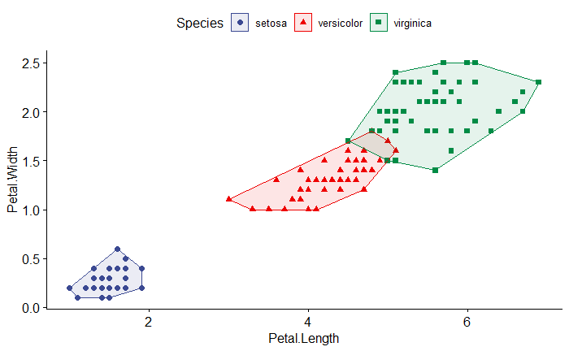

```r
# Plotting Petal Length & Width by Species
ggscatter(iris, x = "Petal.Length", y = "Petal.Width",
          color = "Species", palette = "aaas",
          shape = "Species",
          ellipse = TRUE, ellipse.type = "convex")
```

Now we’ll use ANOVA to examine whether each feature is significantly different between each species. It turns out the species have significant differences in all features. More specifically the test states that at least one pair of species is statistically different from one another for each flower feature. Next Tukey will be used to look at how exactly the species differ for each feature

```r
# Comparing Sepal length between species
sepal.length.aov <- aov(formula = Sepal.Length ~ Species, data = iris)
summary(sepal.length.aov)
```

```
             Df Sum Sq Mean Sq F value Pr(>F)
Species       2  63.21  31.606   119.3 <2e-16 ***
Residuals   147  38.96   0.265
---
Signif. codes:  0 ‘***’ 0.001 ‘**’ 0.01 ‘*’ 0.05 ‘.’ 0.1 ‘ ’ 1
```

```r
# Comparing Sepal Width between species
sepal.width.aov <- aov(formula = Sepal.Width ~ Species, data = iris)
summary(sepal.width.aov)
```

```
             Df Sum Sq Mean Sq F value Pr(>F)
Species       2  11.35   5.672   49.16 <2e-16 ***
Residuals   147  16.96   0.115
---
Signif. codes:  0 ‘***’ 0.001 ‘**’ 0.01 ‘*’ 0.05 ‘.’ 0.1 ‘ ’ 1
```

```r
# Comparing Petal length between species
petal.length.aov <- aov(formula = Petal.Length ~ Species, data = iris)
summary(petal.length.aov)
```

```
             Df Sum Sq Mean Sq F value Pr(>F)
Species       2  437.1  218.55    1180 <2e-16 ***
Residuals   147   27.2    0.19
---
Signif. codes:  0 ‘***’ 0.001 ‘**’ 0.01 ‘*’ 0.05 ‘.’ 0.1 ‘ ’ 1
```

```r
# Comparing Petal width between species
petal.width.aov <- aov(formula = Petal.Width ~ Species, data = iris)
summary(petal.width.aov)
```

```
             Df Sum Sq Mean Sq F value Pr(>F)
Species       2  80.41   40.21     960 <2e-16 ***
Residuals   147   6.16    0.04
---
Signif. codes:  0 ‘***’ 0.001 ‘**’ 0.01 ‘*’ 0.05 ‘.’ 0.1 ‘ ’ 1
```

Below we use Tukey to look into the differences between each species per feature based on the ANOVA tests ran previously. The output shows an estimation of the difference between averages between each species for each feature with 95% confidence i.e. The difference in sepal lengths between versicolor & setosa is 0.930 cm, with versicolor averaging 0.930 cm points higher with p adj = 0 meaning the difference is statistically significant. The 95% confidence interval of their difference is between 0.6862 and 1.1738 cms.

```r
TukeyHSD(x=sepal.length.aov, 'Species', conf.level=0.95)
```

```
  Tukey multiple comparisons of means
    95% family-wise confidence level

Fit: aov(formula = Sepal.Length ~ Species, data = iris)

$Species
                      diff       lwr       upr p adj
versicolor-setosa    0.930 0.6862273 1.1737727     0
virginica-setosa     1.582 1.3382273 1.8257727     0
virginica-versicolor 0.652 0.4082273 0.8957727     0
```

```r
TukeyHSD(x=sepal.width.aov, 'Species', conf.level=0.95)
```

```
  Tukey multiple comparisons of means
    95% family-wise confidence level

Fit: aov(formula = Sepal.Width ~ Species, data = iris)

$Species
                       diff         lwr        upr     p adj
versicolor-setosa    -0.658 -0.81885528 -0.4971447 0.0000000
virginica-setosa     -0.454 -0.61485528 -0.2931447 0.0000000
virginica-versicolor  0.204  0.04314472  0.3648553 0.0087802
```

```r
TukeyHSD(x=petal.length.aov, 'Species', conf.level=0.95)
```

```
  Tukey multiple comparisons of means
    95% family-wise confidence level

Fit: aov(formula = Petal.Length ~ Species, data = iris)

$Species
                      diff     lwr     upr p adj
versicolor-setosa    2.798 2.59422 3.00178     0
virginica-setosa     4.090 3.88622 4.29378     0
virginica-versicolor 1.292 1.08822 1.49578     0
```

```r
TukeyHSD(x=petal.width.aov, 'Species', conf.level=0.95)
```

```
  Tukey multiple comparisons of means
    95% family-wise confidence level

Fit: aov(formula = Petal.Width ~ Species, data = iris)

$Species
                     diff       lwr       upr p adj
versicolor-setosa    1.08 0.9830903 1.1769097     0
virginica-setosa     1.78 1.6830903 1.8769097     0
virginica-versicolor 0.70 0.6030903 0.7969097     0
```

Now we’ve supported the differences between each species with ANOVA we can now create a clustering model. The first step would be to normalize the data. Most algorithms work better with normalized data (scaling data to a range i.e. 0 to 1)

```r
# Separating data between variables and classes (species)
iris.new<- iris[,c(1,2,3,4)]
iris.class<- iris[,"Species"]

# Creating a function to normalize the data based on max min values of each col
normalize <- function(x){
  return (
    ( x-min(x) )/( max(x)-min(x) )
  )
}

iris.new$Sepal.Length<- normalize(iris.new$Sepal.Length)
iris.new$Sepal.Width<- normalize(iris.new$Sepal.Width)
iris.new$Petal.Length<- normalize(iris.new$Petal.Length)
iris.new$Petal.Width<- normalize(iris.new$Petal.Width)

summary(iris.new)
```

```
  Sepal.Length     Sepal.Width      Petal.Length     Petal.Width
 Min.   :0.0000   Min.   :0.0000   Min.   :0.0000   Min.   :0.00000
 1st Qu.:0.2222   1st Qu.:0.3333   1st Qu.:0.1017   1st Qu.:0.08333
 Median :0.4167   Median :0.4167   Median :0.5678   Median :0.50000
 Mean   :0.4287   Mean   :0.4406   Mean   :0.4675   Mean   :0.45806
 3rd Qu.:0.5833   3rd Qu.:0.5417   3rd Qu.:0.6949   3rd Qu.:0.70833
 Max.   :1.0000   Max.   :1.0000   Max.   :1.0000   Max.   :1.00000
```

The K means model works by fitting data into a specified amount of groups “k”. Plotting out the within cluster sum of squares (WSS) helps find the optimal amount for “k”. The results show the sum of square differences basically flatten out with 3 groups, which makes sense with this data since there are only 3 flower species

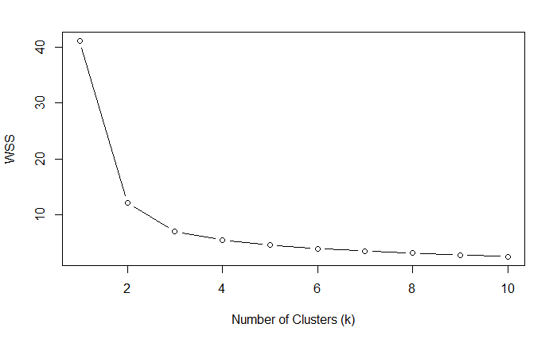

```r
# Setting a seed to make results reproducile + Max K value
set.seed(5)
k.max <- 10

# Running the kmeans algorithm and getting the WSS values for k values from 1-10
wss <- sapply(1:k.max,function(k){
  kmeans(iris.new,k,nstart = 20,iter.max = 20)$tot.withinss
  })

plot(1:k.max,wss, type = "b", xlab = "Number of Clusters (k)", ylab = "WSS")
```

Now we run the model with k = 3 and plot the comparison to the original dataset. Visually the model seemed to do a good job at categorizing the flowers correctly. It has trouble classifying correctly in areas where versicolor and virginica meet

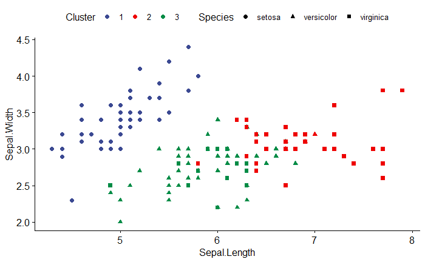

```r
results <- kmeans(iris.new, 3, nstart = 20)

par( mfrow=c(1,2) )

iris_clustered <- data.frame(iris, Cluster=factor(results$cluster))

ggscatter(iris_clustered, x = "Sepal.Length", y = "Sepal.Width",
          color = "Cluster",
          palette = "aaas",
          shape = "Species"
          )
```

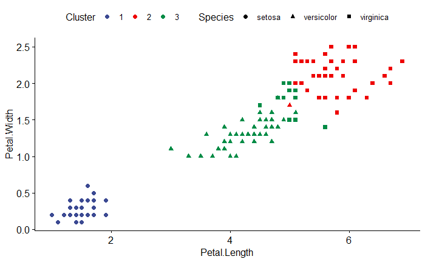

```r
ggscatter(iris_clustered, x = "Petal.Length", y = "Petal.Width",
          color = "Cluster",
          palette = "aaas",
          shape = "Species"
          )
```

As noticed in the graph the model incorrectly classified a few Virgincas (14) and a couple Versicolos (3), but correctly classified all Setosas. With a total of 133 correct classifications the accuracy of the model was 88.7%. If a higher accuracy is desired different K values or potentially different algorithms like k-NN or SVM could possibly yield better results.

```r
table(iris_clustered$Cluster,iris_clustered$Species)
```

[output not shown]